# Aumann Econ Forecasting Homework 1

## 1) Source Description

-The data is on total job opening (non-farm) in the USA (in the thousands).

-The source of the data is from the [U.S. Bureau of Labor Statistics](https://fred.stlouisfed.org/series/JTSJOL), and is hosted on the FRED database maintained by the Federal Reserve Bank of St. Louis.

-This data is useful as an indicator for finding gaps in the demand for labor and could possible be quite useful as an indicator for labor shortages.

-A forecast could be used to find these future labor shortages and help create effective policy to avoid such shortcomings.

## 2) Job Openings Time Series Plot

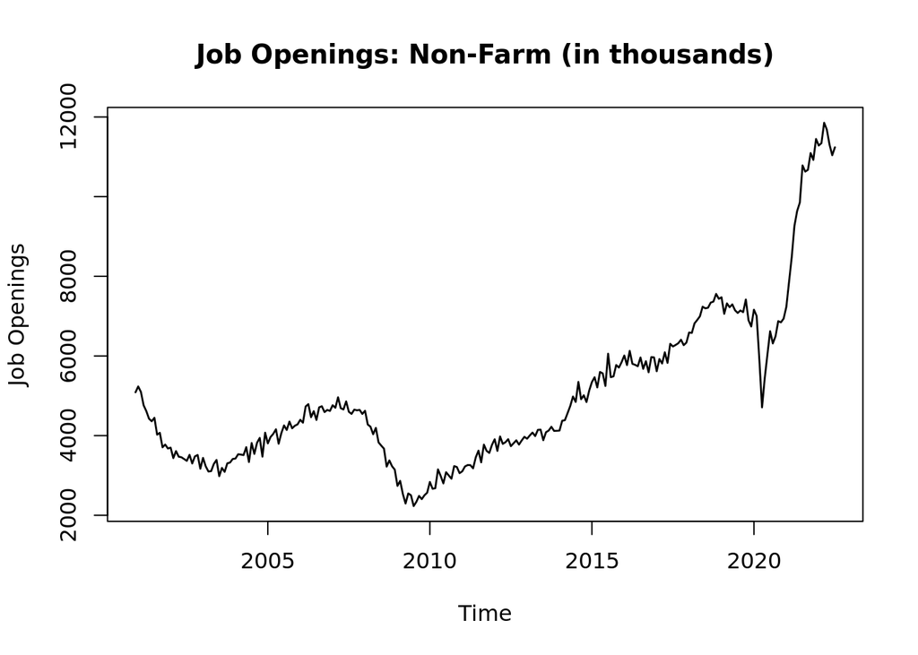

## 3) Simple Forcasts

### Naive

This naive forecast was calculated by using the previous observation (in this case July 2022) to forecast for August and September 2022.

**Step 1** (August 2022): 11,239

**Step 2** (September 2022): 11,239

### Seasonal Naive

This seasonal naive forecast was calculated by using the totals from Q4 2021 and Q1 2022 total to forecast for Q4 2022 and Q1 2023.

-**Step 1** Q4 2022 (total): 33,464

-**Step 2** Q1 2023 (total): 34,482

### Averaging

This is the monthly average. In this case the average totals since 2001 for August and September respectively were calculated to create the forecast.  
-**Step 1** (August 2022):4855.7

-**Step 2** (September 2022):4887.3

## 4) Linear Time Trend

```
##
## Call:
## lm(formula = lhs ~ rhs)
##
## Coefficients:
## (Intercept)          rhs
##     2364.88        20.25
```

-**Step 1** (August 2022):

```
## [1] 7650.13
```

-**Step 2** (September 2022):

```
## [1] 7670.38
```

The regression suggests an upward trend which is expected as job openings have been rising steadily since 2010.  
This expectation is only compounded by the characteristics of the post-COVID labor market.